# Community

Meta Mahyarani

12/8/2020

```r
# untuk data cleaning
library(tidyverse)
library(lubridate)
```

```r
# untuk visualisasi network
library(tidygraph)
library(graphlayouts)

# untuk pengumpulan data Twitter
library(rtweet)
#library untuk pembuatan graph
library(igraph)
library(ggraph)

#library untuk font
library(extrafont)
loadfonts(device = "win")

library(ggpubr) # untuk export plot
```

#Import Data Nodes dan Edges

```r
#baca file nodes dan edges
nodes <- read.csv("nodes.csv")
edges <-  read.csv("edges_baru.csv")
nodes
```

| username |
| --- |
| bibir_sum_sum |
| Teraaan1 |
| NajwaShihab |
| JualanOnline18 |
| StalistS |
| sh_tengku |
| Herman84617774 |
| GajahNata |
| bangaluul |
| dewe_meneh_ |

[output cut: 188 more lines]

```r
edges
```

| from | to | type | count |
| --- | --- | --- | --- |
| 10_igun | Muslim_AntiPKI | retweet | 1 |
| 1MenujuDamai | QaillaAsyiqah | retweet | 1 |
| 2ikhtiar | QaillaAsyiqah | retweet | 1 |
| 30DetikTakHenti | QaillaAsyiqah | retweet | 1 |
| AJazuli5 | JameelaNajma | retweet | 1 |
| Abe_TSFE | kanopimedia | retweet | 1 |
| Adhek_Byt | Muslim_AntiPKI | retweet | 1 |
| Adhek_Byt | QaillaAsyiqah | retweet | 1 |
| Alief1Ba | kanopimedia | retweet | 1 |
| AlifKamal__ | SeknasKPA | retweet | 1 |

[output cut: 204 more lines]

Diatas adalah **user_id** dari akun-akun yang unik yang terdapat pada data munas mutual, berikut koneksinya antar satu dengan yang lain. Untuk menggabungkannya menjadi sebuah data grafik untuk pembuatan **Ego Network**. Gunakan package **igraph**

```r
# buat data.frame untuk grafik network
# lalu menggunakan graph yang undirected
ego_network <- igraph::graph_from_data_frame(d = edges,
                                   vertices = nodes,
                                   directed = F) %>%
  as_tbl_graph()
```

```r
ego_network
```

```
## # A tbl_graph: 198 nodes and 214 edges
## #
## # An undirected multigraph with 13 components
## #
## # Node Data: 198 x 1 (active)
##   name
##   <chr>
## 1 bibir_sum_sum
## 2 Teraaan1
## 3 NajwaShihab
## 4 JualanOnline18
## 5 StalistS
## 6 sh_tengku
## # ... with 192 more rows
## #
## # Edge Data: 214 x 4
##    from    to type    count
##   <int> <int> <chr>   <int>
## 1    12   152 retweet     1
## 2    81   111 retweet     1
## 3    81    85 retweet     1
## # ... with 211 more rows
```

# Buat Komunitas & Hitung Metrics

Setelah membuat data grafik, selanjutnya melengkapi data tersebut dengan metrics-metrics yang umum digunakan pada SNA dan kemungkinan komunitas yang dapat terbentuk pada suatu network. Gunakan **tidygraph** coding style untuk SNA ini agar codingan kita lebih rapih. Style ini juga umum digunakan untuk package **igraph** yang kita gunakan.

Untuk membuat komunitas, terdapat beragam algoritma yang dapat digunakan. Untuk saat ini, akan menggunakan algoritma **group_louvain()*. Kita juga akan menghitung 4 metrics yang berguna untuk pengidentifikasi Key Player atau Influence yang akan dijelaskan di bagian berikutnya.

```r
set.seed(123)
#memproses komunitas
ego_network <- ego_network %>%
  # analisis komunitas dengan menggunakan group louvain
  mutate(community = as.factor(group_louvain())) %>%
  # analisis beragam metrics berdasarkan centrality, betweenness, clossness dan eigen
  mutate(degree_c = centrality_degree()) %>%
  mutate(betweenness_c = centrality_betweenness(directed = T,
                                                normalized = T)) %>%
  mutate(closeness_c = centrality_closeness(normalized = T)) %>%
  mutate(eigen = centrality_eigen(directed = F))
#memproses komunitas dengan menjadikan sebuah dataframe dengan mengatur tidak mengikutsertakan degreenya.
ego_network %>%
  activate(nodes) %>%
  as.data.frame() %>%
  arrange(-degree_c)
```

| name | community | degree_c | betweenness_c | closeness_c | eigen |
| --- | --- | --- | --- | --- | --- |
| QaillaAsyiqah | 1 | 48 | 3.486481e-01 | 0.017220280 | 1.000000e+00 |
| kanopimedia | 2 | 35 | 2.699679e-01 | 0.016988617 | 5.840148e-05 |
| Muslim_AntiPKI | 3 | 19 | 3.408785e-01 | 0.017268583 | 3.421406e-02 |
| Stone98Jade | 4 | 17 | 1.284575e-02 | 0.005744948 | 4.427331e-17 |
| Lini_ZQ | 5 | 14 | 4.307599e-02 | 0.016885232 | 8.836461e-02 |
| SeknasKPA | 6 | 9 | 5.697711e-02 | 0.016632894 | 1.486051e-06 |
| KasbiIndo | 5 | 8 | 1.351911e-02 | 0.016875107 | 6.638773e-02 |
| mathsoul1 | 8 | 8 | 6.137988e-03 | 0.005741599 | 2.399265e-17 |
| FsbnK | 5 | 8 | 1.351911e-02 | 0.016875107 | 6.638773e-02 |
| CasperBeWin1 | 7 | 8 | 4.951828e-02 | 0.016895369 | 9.003255e-04 |

[output cut: 188 more lines]

```r
#memeriksa frekuensi dari community berdasarkan data frame tersebut
ego_network %>%
  activate(nodes) %>%
  as.data.frame()  %>%
  pull(community) %>%
  table()
```

```
## .
##  1  2  3  4  5  6  7  8  9 10 11 12 13 14 15 16 17 18 19
## 47 35 26 17 16 10  9  8  7  5  2  2  2  2  2  2  2  2  2
```

```r
ego_network
```

```
## # A tbl_graph: 198 nodes and 214 edges
## #
## # An undirected multigraph with 13 components
## #
## # Node Data: 198 x 6 (active)
##   name           community degree_c betweenness_c closeness_c    eigen
##   <chr>          <fct>        <dbl>         <dbl>       <dbl>    <dbl>
## 1 bibir_sum_sum  2                1             0     0.0168  8.40e- 6
## 2 Teraaan1       11               1             0     0.00508 9.89e-18
## 3 NajwaShihab    4                1             0     0.00574 1.93e-17
## 4 JualanOnline18 3                1             0     0.0171  4.92e- 3
## 5 StalistS       1                1             0     0.0170  1.44e- 1
## 6 sh_tengku      1                1             0     0.0170  1.44e- 1
## # ... with 192 more rows
## #
## # Edge Data: 214 x 4
##    from    to type    count
##   <int> <int> <chr>   <int>
## 1    12   152 retweet     1
## 2    81   111 retweet     1
## 3    81    85 retweet     1
## # ... with 211 more rows
```

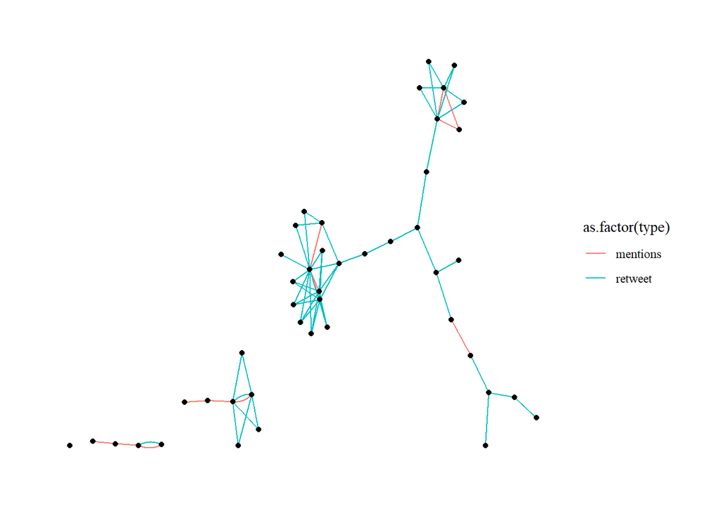

```r
#membuat graph awal berdasarkan degree >1
# Degree >1 ini dimaksudkan untuk menampilkan graph yang memiliki pasangan atau yang memiliki edges agar tidak terjadi island atau nodes yang minim relasi

ego_network %>%
  activate(nodes) %>%
  mutate(degree = centrality_degree()) %>%
  # mutate(node_label = name) %>%
  filter(degree > 1) %>%
  ggraph(layout = "stress") +
  geom_edge_fan(aes(color = as.factor(type))) +
  # geom_node_label(aes(label = node_label)) +
  geom_node_point() +
  theme_graph(base_family = "serif")
```

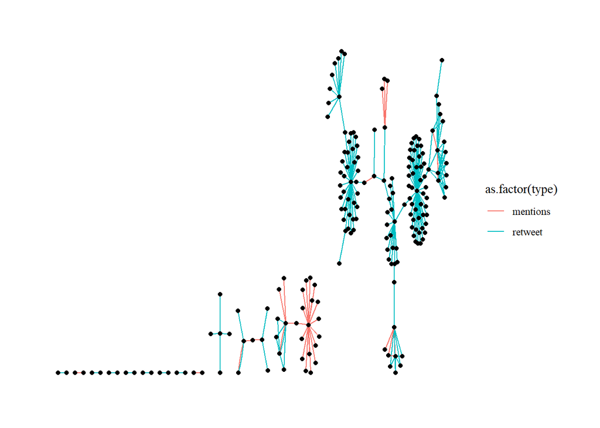

```r
#membuat graph awal berdasarkan degree >1
# Degree >1 ini dimaksudkan untuk menampilkan graph yang memiliki pasangan atau yang memiliki edges agar tidak terjadi island atau nodes yang minim relasi

ego_network %>%
  activate(nodes) %>%
  mutate(degree = centrality_degree()) %>%
  # mutate(node_label = name) %>%
  # filter(degree > 1) %>%
  ggraph(layout = "stress") +
  geom_edge_fan(aes(color = as.factor(type))) +
  # geom_node_label(aes(label = node_label)) +
  geom_node_point() +
  theme_graph(base_family = "serif")
```

# Analisis Key Player

**Key Player** adalah istilah untuk user yang paling berpengaruh dalam suatu network. Umumnya Key Player ditentukan berdasarkan beberapa metrics yang telah dihitung sebelumnya, yaitu:

- **Degree Centrality** adalah node/user yang memiliki relasi terbanyak
- **Closeness Centrality** adalah node/user yang memiliki jarak rata-rata terpendek kesemua node didalam network(berpotensi untuk penyebaran informasi yang lebih cepat).
- **Betweenness Centrality** adalah node/user yang sering berperan sebagai “jembatan informasi” antar node atau komunitas didalam suatu network (berpotensi untuk penyebaran informasi yang lebih luas).
- **Eigen Centrality** adalah node/user yang memiliki kedekatan tinggi dengan node lain yang mempunyai dianalogikan seperti **teman dari seorang influencer**.

```r
#Untuk mencari Key Player atau orang berpengaruh
ego_network_df <- as.data.frame(ego_network)
```

```r
#Key Player atau orang berpengaruh
ego_network_df
```

| name | community | degree_c | betweenness_c | closeness_c | eigen |
| --- | --- | --- | --- | --- | --- |
| bibir_sum_sum | 2 | 1 | 0.000000e+00 | 0.016784528 | 8.403328e-06 |
| Teraaan1 | 11 | 1 | 0.000000e+00 | 0.005076142 | 9.891313e-18 |
| NajwaShihab | 4 | 1 | 0.000000e+00 | 0.005741097 | 1.932366e-17 |
| JualanOnline18 | 3 | 1 | 0.000000e+00 | 0.017057754 | 4.923026e-03 |
| StalistS | 1 | 1 | 0.000000e+00 | 0.017010621 | 1.438890e-01 |
| sh_tengku | 1 | 1 | 0.000000e+00 | 0.017010621 | 1.438890e-01 |
| Herman84617774 | 11 | 1 | 0.000000e+00 | 0.005076142 | 8.722436e-18 |
| GajahNata | 3 | 1 | 0.000000e+00 | 0.017057754 | 4.923026e-03 |
| bangaluul | 2 | 1 | 0.000000e+00 | 0.016784528 | 8.403328e-06 |
| dewe_meneh_ | 2 | 1 | 0.000000e+00 | 0.016784528 | 8.403328e-06 |

[output cut: 188 more lines]

Selanjutnya akan cari **Key Player** untuk tiap-tiap metriks:

```r
kp_ego_network <- data.frame(
  ego_network_df %>% arrange(-degree_c) %>% select(name) %>%
    slice(1:20),
  ego_network_df %>% arrange(-betweenness_c) %>% select(name) %>%
    slice(1:20),
  ego_network_df %>% arrange(-closeness_c) %>% select(name) %>%
    slice(1:20),
  ego_network_df %>% arrange(-eigen) %>% select(name) %>%
    slice(1:20)
)%>%
  setNames(c("Degree", "Betwenness", "Closeness", "Eigen"))
```

[output not shown]

# Analisis Komunitas

Dapat menganalisis adanya komunitas yang dapat terbentuk di suatu network. Package **igraph** mengimplementasikan beberapa algoritma untuk deteksi komunitas diantaranya: - **group_walktrap()** - **group_fast_greedy()** - **group_louvain()**

Pada kasus ini kita menggunakan **group_louvain()** yang menggunakan optimasi modularitas. Rujukan kami berdasarkan artikel jurnal megenai penggunaan metode tersebut. Nilai **modularitas/modularity** sendiri adalah nilai yang menunjukkan seberapa baik tiap komunitas terpisah antara satu sama lain. Secara singkat, network dengan modularity yang tinggi memiliki jaringan yang padat ditiap komunitasnya, namun memiliki koneksi yang jarang antar komunitas yang berbeda.

```r
# total user
nrow(ego_network_df)
```

```
## [1] 198
```

```r
# jumlah komunitas
length(levels(ego_network_df$community))
```

```
## [1] 19
```

```r
# kita dapat hitung nilai modularitasnya
cw_net <- igraph::cluster_louvain(graph = ego_network)
igraph::modularity(cw_net)
```

```
## [1] 0.8413289
```

```r
# sebelumnya kita akan import font untuk visualisasi grafik
library(extrafont)
loadfonts(device = "win")
```

```r
# visualisasi network communitynya berdasarkan degree yang lebih dari 10.
#Nama-nama yang terdapat di graph tersebut berdasarkan degree yang lebih dari 10.
library(ggraph)

plot <- ego_network %>%
  mutate(node_size = ifelse(degree_c >= 10,degree_c,0)) %>%
  mutate(node_label = ifelse(degree_c >= 10,name,"")) %>%
  # filter(degree > 1) %>%
  #menampilkan 10 Community teratas
  filter(community %in% 1:10) %>%
  ggraph(layout = "stress") +
  geom_edge_fan(alpha = 0.05) +
  geom_node_point(aes(color = as.factor(community), size = node_size)) +
  geom_node_label(aes(label = node_label), repel = T,
                 show.legend = F, fontface = "bold", label.size = 0,
                 segment.colour="slateblue", fill = "#ffffff66") +
  coord_fixed() +
  theme_graph(base_family = "serif") +
  theme(legend.position = "right", plot.title = element_text(size = rel(1), family = "serif")) +
  labs(title = "10 Community Networks",
       color = "Community", size = "Degree Centrality")

plot
```

[output not shown]

```r
# visualisasi network communitynya berdasarkan degree yang lebih dari 10.
#Nama-nama yang terdapat di graph tersebut berdasarkan degree yang lebih dari 10.
library(ggraph)

plot_tanpalabel <- ego_network %>%
  mutate(node_size = ifelse(degree_c >= 10,degree_c,0)) %>%
  # mutate(node_label = ifelse(degree_c >= 10,name,"")) %>%
  # filter(degree > 1) %>%
  #menampilkan 10 Community teratas
  filter(community %in% 1:10) %>%
  ggraph(layout = "stress") +
  geom_edge_fan(alpha = 0.05) +
  geom_node_point(aes(color = as.factor(community), size = node_size)) +
  # geom_node_label(aes(label = node_label), repel = T,
  #                show.legend = F, fontface = "bold", label.size = 0,
  #                segment.colour="slateblue", fill = "#ffffff66") +
  coord_fixed() +
  theme_graph(base_family = "serif") +
  theme(legend.position = "right", plot.title = element_text(size = rel(1), family = "serif")) +
  labs(title = "10 Community Networks",
       color = "Community", size = "Degree Centrality")

plot_tanpalabel
```

[output not shown]

```r
# menyimpan plot di direktori lokal
saveRDS(plot,"plot.rds")
save
```

[output not shown]

[output cut: 14 more lines]

[output not shown]